### Table of Contents

- Part 1: Data
- Part 2: Data Manipulation
- Part 3: Exploratory data analysis
  - Part 3.1 : Between seasons and audience score
  - Part 3.2 : Between feature_film and audience score
  - Part 3.3 : Audience score vs drama
  - Part 3.4 : Audience score vs mpaa_rating_R
- Part 4: Modeling
  - Part 4.1 : Model Selection
  - Part 4.2 : Model diagnostics
  - Part 4.3 : Interpretation of the model co-efficients
- Part 5: Prediction
- Part 6: Conclusion

### Load packages

```r
library(MASS)
library(tidyverse)
library(statsr)
library(BAS)
library(broom)
```

### Load data

```r
load("movies.Rdata")
```

## Part 1: Data

As it was mentioned first that the data set is comprised of 651 *randomly sampled* movies produced and released before 2016, we can conclude that the conclusion derived are generalizable and can be applied to the population.

It is *not causal* as there is no random assignment. So we can’t find reason on why people like a movie or not.

## Part 2: Data manipulation

creating additional variables

```r
movies <- movies %>% mutate(feature_film = ifelse(title_type == "Feature Film", "yes", "no"))
movies <- movies %>% mutate(drama = ifelse(genre == "Drama", "yes", "no"))
movies <- movies %>% mutate(mpaa_rating_R = ifelse(mpaa_rating == "R", "yes", "no"))
movies <- movies %>% mutate(oscar_season = ifelse(thtr_rel_month == 10 | thtr_rel_month == 11 | thtr_rel_month == 12, "yes", "no"))
movies <- movies %>% mutate(summer_season = ifelse(thtr_rel_month == 5 | thtr_rel_month == 6 | thtr_rel_month == 7 | thtr_rel_month == 8, "yes", "no"))
```

```r
str(movies$feature_film)
```

```
##  chr [1:651] "yes" "yes" "yes" "yes" "yes" "no" "yes" "yes" "no" "yes" ...
```

```r
str(movies$drama)
```

```
##  chr [1:651] "yes" "yes" "no" "yes" "no" "no" "yes" "yes" "no" "yes" ...
```

```r
str(movies$mpaa_rating_R)
```

```
##  chr [1:651] "yes" "no" "yes" "no" "yes" "no" "no" "yes" "no" "no" ...
```

```r
str(movies$oscar_season)
```

```
##  chr [1:651] "no" "no" "no" "yes" "no" "no" "no" "yes" "no" "no" "no" ...
```

```r
str(movies$summer_season)
```

```
##  chr [1:651] "no" "no" "yes" "no" "no" "no" "no" "no" "no" "no" "yes" ...
```

## Part 3: Exploratory data analysis

### Part 3.1 : Between seasons and audience score

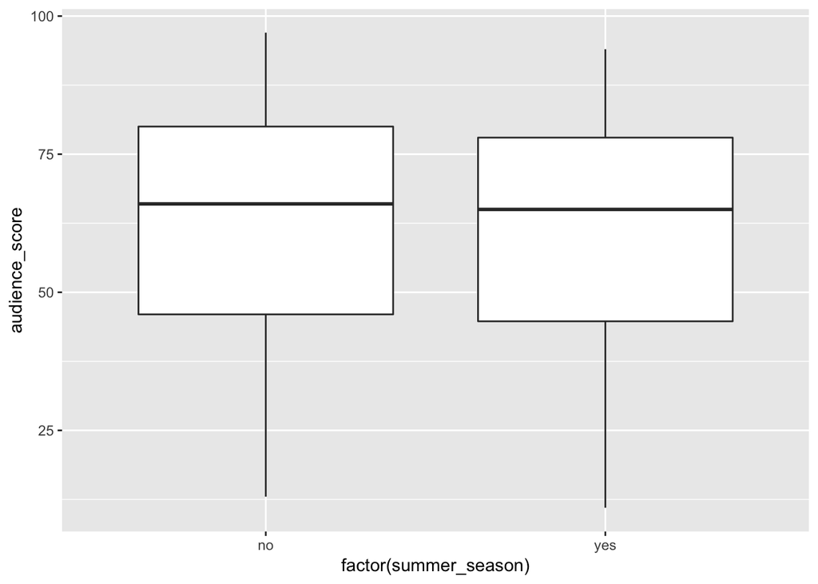

```r
ggplot(movies, aes(x = factor(summer_season), y = audience_score)) + geom_boxplot()
```

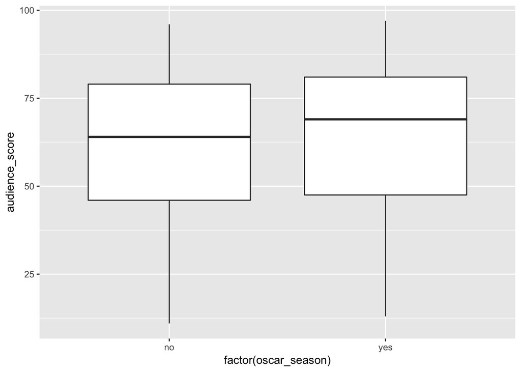

```r
ggplot(movies, aes(x = factor(oscar_season), y = audience_score)) + geom_boxplot()
```

Seems there is no difference based on the season in which the movie is released, as the plot looks similar in both the cases. So these variables are not at all related to each other.

### Part 3.2 : Between feature_film and audience score

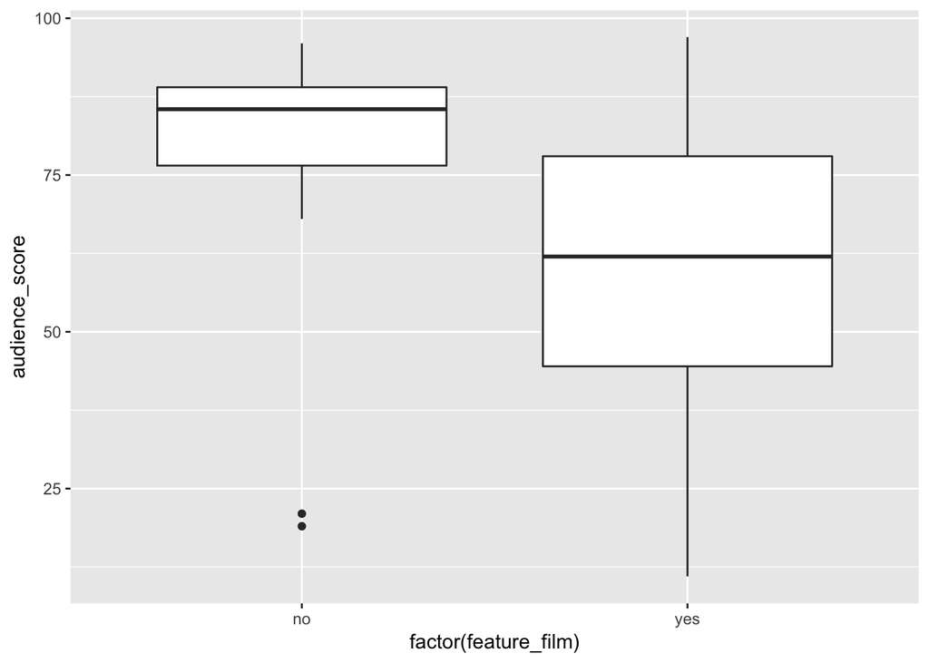

```r
ggplot(movies, aes(x = factor(feature_film), y = audience_score)) + geom_boxplot()
```

Compared to the ‘feature films’ other types like ‘Documentaries and TV movies’ get much higher rating

### Part 3.3 : Audience score vs drama

```r
movies %>% group_by(drama) %>% summarise(min=min(audience_score), max=max(audience_score), iqr=IQR(audience_score), sd=sd(audience_score))
```

```
## # A tibble: 2 x 5
##   drama   min   max   iqr    sd
##   <chr> <dbl> <dbl> <dbl> <dbl>
## 1 no       11    97    38  21.3
## 2 yes      13    95    28  18.5
```

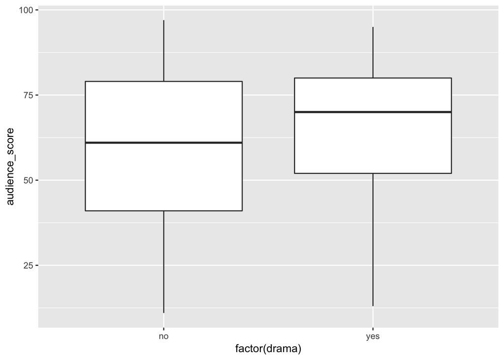

```r
ggplot(movies, aes(x = factor(drama), y = audience_score)) + geom_boxplot()
```

In case of Drama, people preferred it a bit more than non-drama movies (based on 25-75% quantiles)

### Part 3.4 : Audience score vs mpaa_rating_R

```r
movies %>% group_by(mpaa_rating_R) %>% summarise(min=min(audience_score), max=max(audience_score), iqr=IQR(audience_score), sd=sd(audience_score))
```

```
## # A tibble: 2 x 5
##   mpaa_rating_R   min   max   iqr    sd
##   <chr>         <dbl> <dbl> <dbl> <dbl>
## 1 no               11    96  31.8  20.3
## 2 yes              14    97  35    20.2
```

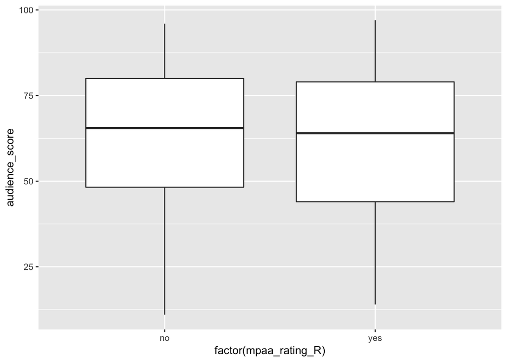

```r
ggplot(movies, aes(x = factor(mpaa_rating_R), y = audience_score)) + geom_boxplot()
```

Seems not much of a difference in the audience score

## Part 4: Modeling

### Part 4.1 : Model Selection

For this, we will use backward elimination with BIC . Let’s include all the params and get the BIC.

```r
movies_no_na <- na.omit(movies)

mlm_movie <- lm(audience_score ~ feature_film + drama + runtime + mpaa_rating_R + thtr_rel_year + oscar_season + summer_season + imdb_rating + imdb_num_votes + critics_score + best_pic_nom + best_pic_win + best_actor_win + best_actress_win + best_dir_win + top200_box, data = movies_no_na)

BIC(mlm_movie)
```

```
## [1] 4716.774
```

BIC is `4716.774`

```r
BIC(lm(audience_score ~ feature_film + drama + runtime + mpaa_rating_R + thtr_rel_year + oscar_season + summer_season + imdb_rating + imdb_num_votes + critics_score + best_pic_nom + best_pic_win + best_actor_win + best_actress_win + best_dir_win, data = movies_no_na))
```

```
## [1] 4710.428
```

BIC is `4710.428`. So remove the variable `top200_box`

```r
BIC(lm(audience_score ~ feature_film + drama + runtime + mpaa_rating_R + thtr_rel_year + summer_season + imdb_rating + imdb_num_votes + critics_score + best_pic_nom + best_pic_win + best_actor_win + best_actress_win + best_dir_win, data = movies_no_na))
```

```
## [1] 4704.099
```

BIC is `4704.099`, so remove the variable `oscar_season`

```r
BIC(lm(audience_score ~ feature_film + drama + runtime + mpaa_rating_R + thtr_rel_year + summer_season + imdb_rating + imdb_num_votes + critics_score + best_pic_nom + best_actor_win + best_actress_win + best_dir_win, data = movies_no_na))
```

```
## [1] 4698.11
```

BIC is `4698.11`, so remove the variable `best_pic_win`

```r
BIC(lm(audience_score ~ feature_film + drama + runtime + mpaa_rating_R + thtr_rel_year + summer_season + imdb_rating + imdb_num_votes + critics_score + best_pic_nom + best_actor_win + best_actress_win, data = movies_no_na))
```

```
## [1] 4692.601
```

BIC is `4692.601`, so remove the variable `best_dir_win`

```r
BIC(lm(audience_score ~ feature_film + drama + runtime + mpaa_rating_R + thtr_rel_year + summer_season + imdb_rating + imdb_num_votes + critics_score + best_pic_nom + best_actress_win, data = movies_no_na))
```

```
## [1] 4687.432
```

BIC is `4687.432`, so remove the variable `best_actor_win`

```r
BIC(lm(audience_score ~ feature_film + drama + runtime + mpaa_rating_R + thtr_rel_year + imdb_rating + imdb_num_votes + critics_score + best_pic_nom + best_actress_win, data = movies_no_na))
```

```
## [1] 4682.776
```

BIC is `4682.776`, so remove the variable `summer_season`

```r
BIC(lm(audience_score ~ drama + runtime + mpaa_rating_R + thtr_rel_year + imdb_rating + imdb_num_votes + critics_score + best_pic_nom + best_actress_win, data = movies_no_na))
```

```
## [1] 4678.23
```

BIC is `4678.23`, so remove the variable `feature_film`

```r
BIC(lm(audience_score ~ runtime + mpaa_rating_R + thtr_rel_year + imdb_rating + imdb_num_votes + critics_score + best_pic_nom + best_actress_win, data = movies_no_na))
```

```
## [1] 4673.041
```

BIC is `4673.041`, so remove the variable `drama`

```r
BIC(lm(audience_score ~ runtime + mpaa_rating_R + thtr_rel_year + imdb_rating + critics_score + best_pic_nom + best_actress_win, data = movies_no_na))
```

```
## [1] 4668.281
```

BIC is `4668.281`, so remove the variable `imdb_num_votes`

```r
BIC(lm(audience_score ~ runtime + mpaa_rating_R + imdb_rating + critics_score + best_pic_nom + best_actress_win, data = movies_no_na))
```

```
## [1] 4663.531
```

BIC is `4663.531`, so remove the variable `thtr_rel_year`

```r
BIC(lm(audience_score ~ runtime + mpaa_rating_R + imdb_rating + critics_score + best_pic_nom, data = movies_no_na))
```

```
## [1] 4660.204
```

BIC is `4660.204`, so remove the variable `best_actress_win`

```r
BIC(lm(audience_score ~ runtime + mpaa_rating_R + imdb_rating + critics_score, data = movies_no_na))
```

```
## [1] 4656.76
```

BIC is `4656.76`, so remove the variable `best_pic_nom`

```r
BIC(lm(audience_score ~ runtime + imdb_rating + critics_score, data = movies_no_na))
```

```
## [1] 4653.581
```

BIC is `4653.581`, so remove the variable `mpaa_rating_R`

We can’t remove anything else. Our final variables are `runtime`, `critics_score` and `imdb_rating`

### Part 4.2 : Model diagnostics

In order to do so we will use predicted values, residuals, and standardized residuals of the model we fit earlier. The augment function in the broom package is going to come in handy here as it takes in a model object (the output of an `lm`) and returns a data frame with columns correspinding to variables in the model as well as predicted values (`.fitted`), residuals (`.resid`), and standardized residuals (`.std.resid`), along with a few others.

```r
mlm_movie_model <- lm(audience_score ~ runtime + imdb_rating + critics_score, data = movies_no_na)
summary(mlm_movie_model)
```

```
##
## Call:
## lm(formula = audience_score ~ runtime + imdb_rating + critics_score,
##     data = movies_no_na)
##
## Residuals:
##     Min      1Q  Median      3Q     Max
## -26.996  -6.706   0.738   5.435  52.550
##
## Coefficients:
##                Estimate Std. Error t value Pr(>|t|)
## (Intercept)   -32.90825    3.35451  -9.810  < 2e-16 ***
## runtime        -0.05791    0.02238  -2.588 0.009891 **
## imdb_rating    14.95043    0.60249  24.814  < 2e-16 ***
## critics_score   0.07531    0.02227   3.381 0.000769 ***
## ---
## Signif. codes:  0 '***' 0.001 '**' 0.01 '*' 0.05 '.' 0.1 ' ' 1
##
## Residual standard error: 10.15 on 615 degrees of freedom
## Multiple R-squared:  0.7483, Adjusted R-squared:  0.747
## F-statistic: 609.4 on 3 and 615 DF,  p-value: < 2.2e-16
```

```r
mlm_movie_model_aug <- augment(mlm_movie_model)
```

#### Part 4.2.1 : Linearity and Constant Variance:

We can verify this condition with a plot of the residuals vs. fitted (predicted) values.

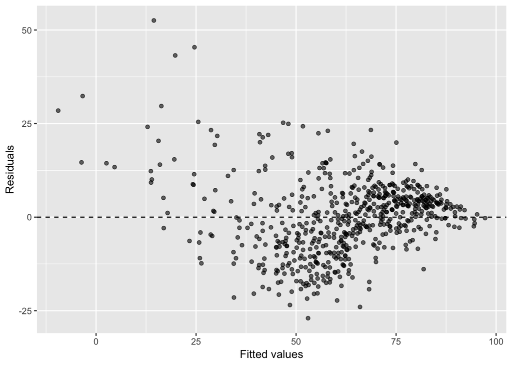

```r
ggplot(data = mlm_movie_model_aug, aes(x = .fitted, y = .resid)) +
  geom_point(alpha = 0.6) +
  geom_hline(yintercept = 0, linetype = "dashed") +
  labs(x = "Fitted values", y = "Residuals")
```

#### Part 4.2.2 : Normality:

To check this condition, we can look at a histogram of residuals

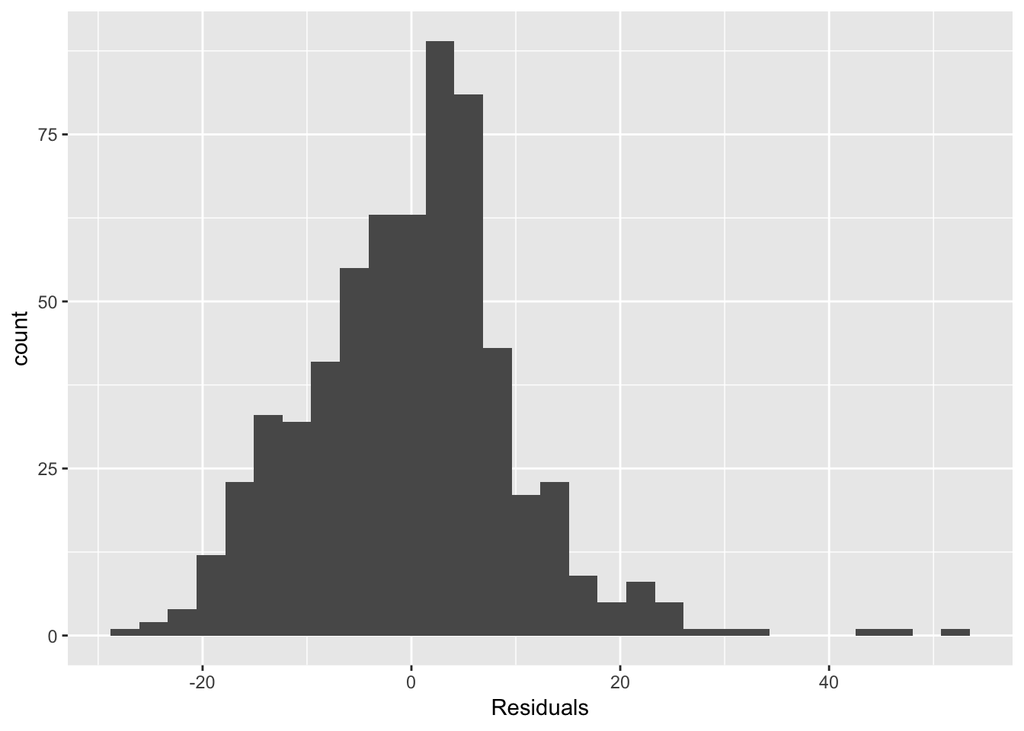

```r
ggplot(data = mlm_movie_model_aug, aes(x = .resid)) +
  geom_histogram() +
  xlab("Residuals")
```

or a normal probability plot of the residuals

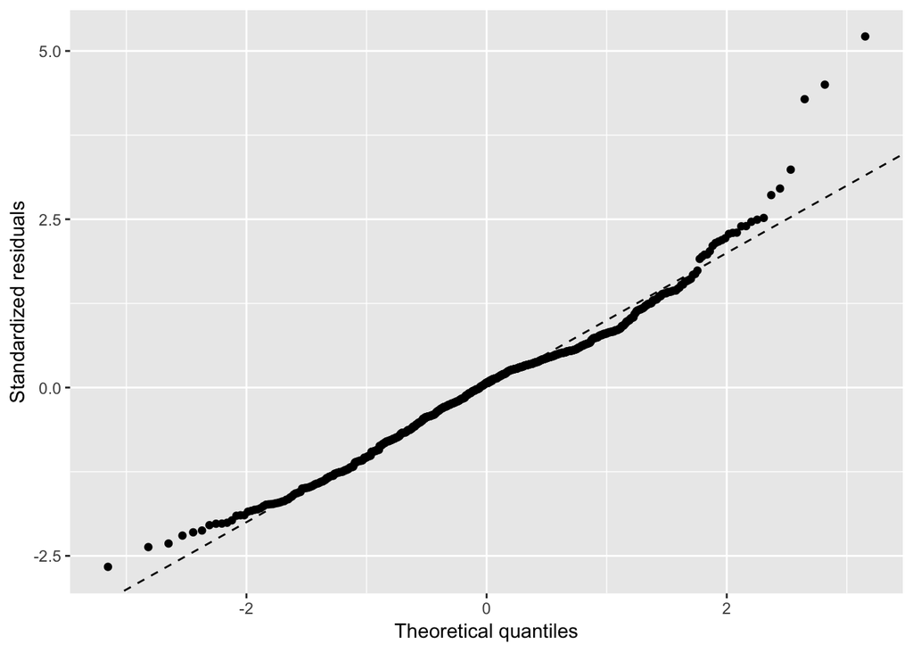

```r
ggplot(mlm_movie_model_aug) +
  geom_qq(aes(sample = .std.resid)) +
  geom_abline(slope = 1, intercept = 0, linetype = "dashed") +
  labs(x = "Theoretical quantiles", y = "Standardized residuals")
```

#### Part 4.2.3 : Outliers

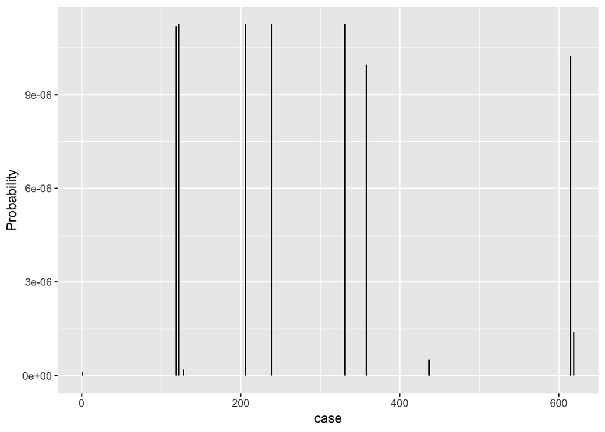

```r
outliers <- Bayes.outlier(mlm_movie_model, k = 3)
outliers_df <- data.frame(probability = outliers$prob.outlier,
                          case = 1:length(outliers$prob.outlier))
ggplot(outliers_df, aes(ymax = probability, x = case)) +
  geom_linerange(ymin = 0) +
  labs(y = "Probability")
```

Outliers with prob > 0.5 is

```r
outliers_df %>%
  filter(probability > 0.50)
```

```
## [1] probability case
## <0 rows> (or 0-length row.names)
```

### Part 4.3 : Interpretation of the model co-efficients

Build model with the predicted params

```r
bma_movie_model <- bas.lm(audience_score ~ runtime + imdb_rating + critics_score, data = movies_no_na,
                   prior = "BIC",
                   modelprior = uniform())

bma_movie_model
```

```
##
## Call:
## bas.lm(formula = audience_score ~ runtime + imdb_rating + critics_score,
##     data = movies_no_na, prior = "BIC", modelprior = uniform())
##
##
##  Marginal Posterior Inclusion Probabilities:
##     Intercept        runtime    imdb_rating  critics_score
##        1.0000         0.5397         1.0000         0.9323
```

```r
coef_movie <- coefficients(bma_movie_model)
coef_movie
```

```
##
##  Marginal Posterior Summaries of Coefficients:
##
##  Using  BMA
##
##  Based on the top  8 models
##                post mean  post SD   post p(B != 0)
## Intercept      62.21002    0.40900   1.00000
## runtime        -0.03138    0.03333   0.53966
## imdb_rating    14.89079    0.72722   1.00000
## critics_score   0.07129    0.02889   0.93233
```

From the co-efficients, for the prediction of the `audience_score` we need `intercept 100%`, `imdb_rating 100%`, `critics_score 93.233%` and with a very less `53.966% runtime`.

Same can be visually interpreted as

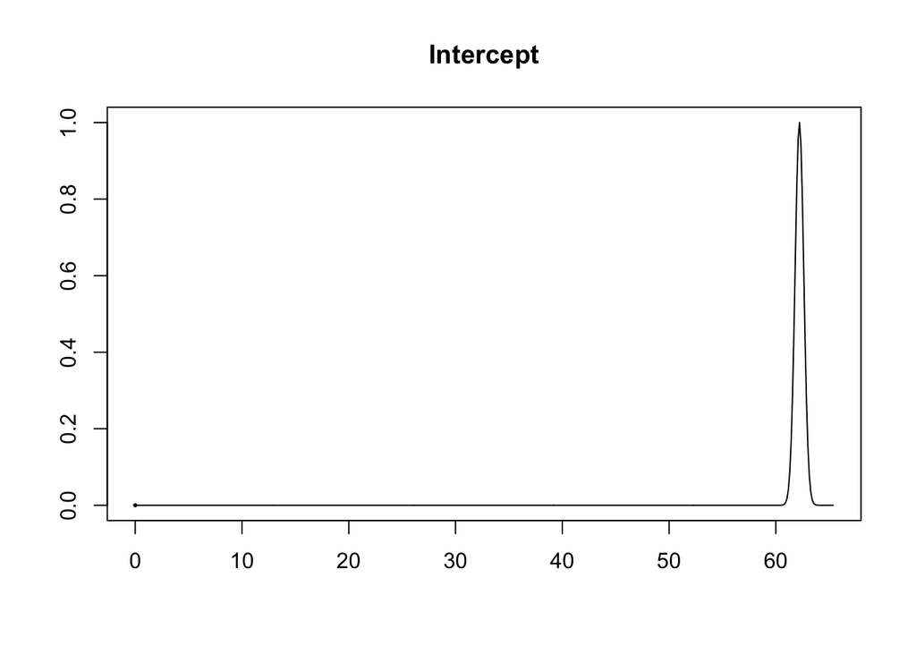

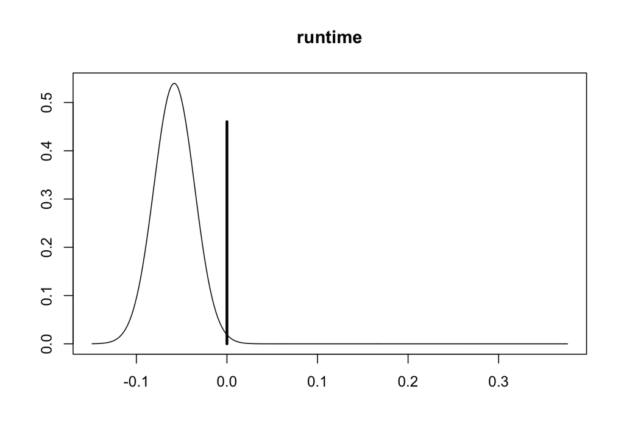

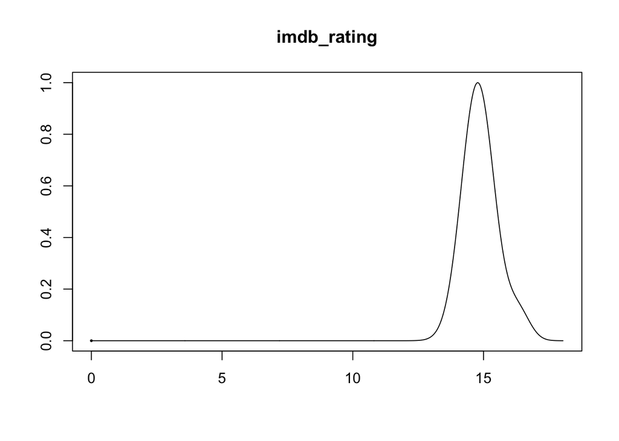

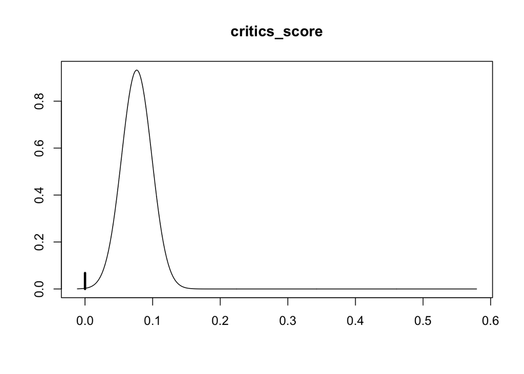

```r
plot(coef_movie, subset = c(1,2,3,4), ask = FALSE)
```

## Part 5: Prediction

Let’s predict the `audience_score` for the 2016 movie `ROGUE ONE: A STAR WARS STORY` using `BMA`

First check if it already there in the sample

```r
movies %>% filter(grepl("rogue", title) | grepl("star", title)) %>% select(title)
```

```
## # A tibble: 1 x 1
##   title
##   <chr>
## 1 Bastard out of Carolina
```

No, it is safe to proceed.

```r
movie_pred <- data.frame(runtime = c(133), imdb_rating=c(7.8), critics_score=c(84))
bma_predict <- predict(bma_movie_model, newdata=movie_pred, se.fit = TRUE, estimator = "BMA")
ci_bma_predict_movie <- confint(bma_predict, estimator = "BMA")
ci_bma_predict_movie
```

```
##          2.5%    97.5%     pred
## [1,] 63.15778 102.8948 82.84599
## attr(,"Probability")
## [1] 0.95
## attr(,"class")
## [1] "confint.bas"
```

Original Audience Score is `86%`

Predicted Audience Score is `83%`

It is a acceptable score. Hence our model works

References : [IMDB Link](https://www.imdb.com/title/tt3748528/) and [Rotten tomatoes link](https://www.rottentomatoes.com/m/rogue_one_a_star_wars_story/)

[figure not shown]

[figure not shown]

## Part 6: Conclusion

1. All else held constants, having the `imdb_rating` (with 100%) in our model will increase the `audience_score` by `14.95043` compared to increase of only `0.07531` by `critics_score` (with 93.233%). So it is clear that imdb rating (given by users) are weighed more than critics score
2. Some good params like `mpaa_rating_R`, `best_pic_nom`, `best_pic_win` has no voice over the `audience_score`

But there are cases where the model fails if the critics like the movie too much and film type is of non-drama, the audience score???s could be low due to other factors like bad movie plot. As adj-r-squared value is `74.7%`, there are still hefty of chances where the prediction will still go wrong.